# Filtering of VCF

J. Ignacio Lucas Lledó

1/12/2021

R allows me to import a matrix of genotype depths, obtained with the `--geno-depth` option in `vcftools` and explore the effect of different filtering settings. This is important because the result of removing individuals and sites iteratively from a data set is different from doing it all at once. At least, if you decide what individuals remove based on what portion of SNPs they have genotyped.

## Analysis of the original filtering

Before cleaning up my data set, made up with only forward reads, I want to check if I can reproduce Kristýna's filtering. Basically, departing from the complete, 90-individuals data set, which included indels, she selected 75 individuals (`popmap_erca_only_good.txt`), and required: minimum genotype depth of 8, exactly 2 alleles, minimum MAF of 0.0125 (not 0.125, as mentioned in the manuscript), minimum SNP quality of 50, minimum portion of SNPs genotyped per site of 0.75, 261 bases of separation between SNPs, and no indels. She obtained 12145 SNPs. However, upon inspection of them, in file `/data/kristyna/hedgehog/results_2021/2021-04-13/erinaceus_merged_2021_q20.recode.vcf`, I see that there are actually only 10777 site, not 12145, with at least 75% of individuals with depth >= 8. The order in which `vcftools` applies the filters is unclear and could result in this difference.

First, I generate a genotype-depth matrix from Kristina's freebayes output, `all_merged_2021.vcf`.

```bash
KDIR=/data/kristyna/hedgehog/results_2021/2021-04-13
if [ ! -e K0.gdepth ]; then
   vcftools --vcf $KDIR/all_merged_2021.vcf \
            --maf 0.0125 \
            --min-alleles 2 \
            --max-alleles 2 \
            --minQ 50 \
            --remove-indels \
            --geno-depth \
            --out K0 &> K0.gdepth.log
fi
if [ ! -e mapped.txt ]; then
   cp ../2021-11-22/mapped.txt ./
fi

if [ ! -e popfile.txt ]; then
   cp ../2021-11-22/popfile.txt ./
fi
```

And I load it in the R session:

```r
mapped <- read.table('mapped.txt', col.names = c('sample','numReads'), row.names = 1)
popula <- read.table('popfile.txt', col.names = c('sample','pop'), row.names = 1)
mapped$pop <- popula[rownames(mapped), 'pop']
mapped$run <- factor(1, levels=c(1,2))
mapped[grep(paste(c('^Er(26', as.character(26:74), '75)_'), collapse = '|'),
            rownames(mapped), value = TRUE, perl = TRUE), 'run'] <- 1
mapped[grep(paste(c('^Er(76', as.character(77:114), '115)_'), collapse = '|'),
            rownames(mapped), value = TRUE, perl = TRUE), 'run'] <- 2

K0.gdepth <- read.table('K0.gdepth', as.is = TRUE, header = TRUE)
K0 <- as.matrix(K0.gdepth[, -c(1,2)])
K0[K0 == -1] <- 0

eog_file <- '/data/kristyna/hedgehog/results_2021/2021-04-13/popmap_erca_only_good.txt'
erca_only_good <- read.table(eog_file,
                             col.names = c('Sample','PopNum'),
                             colClasses = c('character', 'NULL'))[,1]
mapped$inK1 <- factor('bad', levels = c('good','bad'))
mapped[erca_only_good, 'inK1'] <- 'good'

K1 <- K0[, erca_only_good]
f  <- rowSums(K1 >= 8) / ncol(K1) >= 0.75
sum(f)
```

```
## [1] 21774
```

It seems that the thinning of SNPs by distance is performed after sites pass the filters. But if I do not set the `--minDP` or `--max-missing` filters, the thinning out can remove sites that would otherwise pass those filters. And then, we end up with fewer sites. For the purpose of creating the genotypes depth matrix, it is better not to use `--thin`.

```r
mapped$minDP8 <- sapply(rownames(mapped), function(x) sum(K0[,x] >= 8))
lowest15 <- rownames(head(mapped[order(mapped$numReads),], n=15))
stopifnot(sum(lowest15 %in% rownames(head(mapped[order(mapped$minDP8),], n=15))) == 15)

K2 <- K0[, setdiff(colnames(K0), lowest15)]
f  <- rowSums(K2 >= 8) / ncol(K2) >= 0.75
sum(f)
```

```
## [1] 36812
```

```r
f <- rowSums(K0 >= 8) / ncol(K0) >= 0.3
sum(f)
```

```
## [1] 758859
```

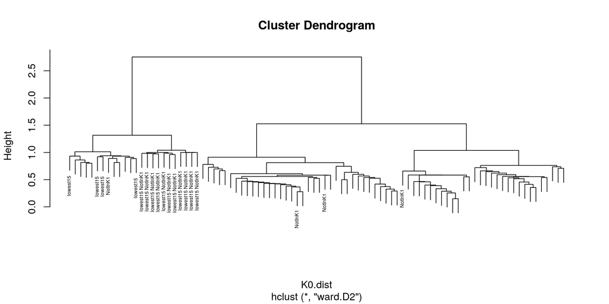

```r
K0.dist <- dist(t(K0[f,] >= 8), method = 'binary')
K0.hc   <- hclust(K0.dist, method = 'ward.D2')
plot(K0.hc, cex=0.5, labels = paste(c('','lowest15')[1 + (K0.hc$labels %in% lowest15)],
                                    c('NotInK1','')[1 + (K0.hc$labels %in% erca_only_good)],
                                    sep = ' '))
```

Some samples missing in `/data/krystina/hedgehog/results_2021/2021-04-13/popmap_erca_only_good.txt` actually have quite large numbers of SNPs covered at least 8 times. If instead of removing the 15 samples in that file we remove the 15 samples with lowest number of SNPs covered at least 8 times (the same as the 15 samples with lowest count of mapped reads), we improve the number of SNPs available for 75 samples: 36812 (before thinning) instead of 21774.

## Filtering forward reads

What if I use only forward reads? If samples from the second batch did not get reverse reads sequenced, they cannot have SNPs in reverse reads covered at all. Thus, most of the SNPs removed from the analysis must be from reverse reads loci. The analysis would be cleaner if we exclude them from the beginning.

```bash
VCF='../2021-11-22/forward.vcf'

if [ ! -e forward.gdepth ]; then
   vcftools --vcf $VCF \
            --maf 0.0125 \
            --remove-indels \
            --min-alleles 2 \
            --max-alleles 2 \
            --minQ 50 \
            --out forward \
            --geno-depth &> forward.gdepth.log &
fi
wait
```

```r
# Finally, not used.
TrimSites <- function(x, minDP = 4, maxMissing = 65/86) {
   filter <- rowSums(x >= minDP) / ncol(x) >= maxMissing
   return(x[filter,])
}

TrimInds <- function(x, minDP = 4, minGenotypes = 0.5) {
   keep <- names(which(colSums(x >= minDP) / nrow(x) >= minGenotypes))
   return(x[, keep])
}

Fullness <- function(x, minDP = 6) {
   sum(x >= minDP) / (dim(x)[1] * dim(x)[2])
}

Thinning <- function(x, minDist = 150) {
   stopifnot(is.data.frame(x))
   stopifnot('CHROM' %in% names(x))
   stopifnot('POS' %in% names(x))
   SameContig <- x$CHROM == c('nothing', x[1:(dim(x)[1] - 1), 'CHROM'])
   Intervals  <- x$POS - c(0, x[1:(dim(x)[1] - 1), 'POS'])
   Intervals[! SameContig] <- minDist
   return(x[Intervals >= minDist, ])
}
```

```r
forwardGdepth <- read.table('forward.gdepth', as.is = TRUE, header = TRUE)
forwardMatrix <- as.matrix(forwardGdepth[, -c(1,2)])
forwardMatrix[forwardMatrix == -1] <- 0
rownames(forwardMatrix) <- paste(forwardGdepth$CHROM, forwardGdepth$POS, sep = ':')
rownames(forwardGdepth) <- paste(forwardGdepth$CHROM, forwardGdepth$POS, sep = ':')
minDP = 8
```

```r
# In the forward-reads data set I already removed the 4 samples with lowest
# count of mapped reads.
mapped$minDP8forward <- sapply(rownames(mapped), function(x) {
   ifelse(x %in% colnames(forwardMatrix), sum(forwardMatrix[,x] >= 8), 0)})
lowest15f <- rownames(head(mapped[order(mapped$minDP8forward),], n=15))
# These are the same as before.

fM1 <- forwardMatrix[, setdiff(colnames(forwardMatrix), lowest15f)]
f  <- rowSums(fM1 >= 8) / ncol(fM1) >= 0.75
sum(f)
```

```
## [1] 33427
```

Even using SNPs found only among forward reads, I manage to keep a larger number of SNPs with a minimum coverage of 8 and a minimum of 75% of samples genotyped than when using the original filtering of individuals. However, applying the new filtering to the full data set yielded even more sites. Thus, I should keep using the full dataset, with forward and reverse reads. After all, the excess of sites from reverse reads are efficiently removed in the filtering step.

## The samples removed

```r
library(knitr)
mapped$lowest15 <- factor('good', levels = c('good','bad'))
mapped[lowest15, 'lowest15'] <- 'bad'
kable(mapped[order(mapped$minDP8),])
```

|  | numReads | pop | run | inK1 | minDP8 | minDP8forward | lowest15 |
| --- | --- | --- | --- | --- | --- | --- | --- |
| Er59_FR1 | 109816 | europaeus | 1 | bad | 10 | 0 | bad |
| Er68_PRT1B | 130774 | europaeus | 1 | bad | 11 | 0 | bad |
| Er62_GR95 | 328292 | roumanicus | 1 | bad | 51 | 0 | bad |
| Er61_GR87 | 582482 | roumanicus | 1 | bad | 544 | 0 | bad |
| Er111_Saratov111 | 2429352 | roumanicus | 2 | bad | 12722 | 14146 | bad |
| Er67_IT5 | 2753406 | europaeus | 1 | bad | 31579 | 14572 | bad |
| Er108_VLD2013 | 3214473 | europaeus | 2 | bad | 31674 | 35604 | bad |
| Er58_FI7 | 2864304 | europaeus | 1 | bad | 32906 | 29067 | bad |
| Er36_SK24 | 3353788 | roumanicus | 1 | bad | 33564 | 26887 | bad |
| Er57_COR4 | 3547039 | europaeus | 1 | bad | 59645 | 35349 | bad |
| Er110_Krasngr | 4493954 | europaeus | 2 | bad | 73497 | 85565 | bad |
| Er38_LB1 | 4007403 | concolor | 1 | good | 92215 | 86118 | bad |
| Er46_RMN7 | 3711203 | roumanicus | 1 | good | 94415 | 89801 | bad |
| Er109_NVB | 4783981 | roumanicus | 2 | good | 109649 | 122942 | bad |
| Er35_209 | 4726786 | roumanicus | 1 | good | 133480 | 133338 | bad |
| Er50_R3 | 5449731 | roumanicus | 1 | good | 187037 | 188986 | good |
| Er26_JUG4 | 5137731 | roumanicus | 1 | good | 187393 | 150961 | good |
| Er75_TRC2A | 5038159 | concolor | 1 | good | 211800 | 202558 | good |
| Er33_211 | 5518676 | europaeus | 1 | good | 215503 | 226434 | good |
| Er72_SIE1B | 4960257 | europaeus | 1 | good | 226935 | 167645 | good |
| Er73_SNG1 | 5029577 | atelerix | 1 | bad | 233556 | 214198 | good |
| Er60_GR5 | 5241532 | roumanicus | 1 | good | 246848 | 249964 | good |
| Er76_Ch8f | 8340881 | europaeus | 2 | good | 310949 | 359380 | good |
| Er52_451 | 5902522 | europaeus | 1 | good | 337861 | 336899 | good |
| Er79_Ch19 | 8285885 | roumanicus | 2 | good | 367241 | 425236 | good |
| Er78_Ch11 | 7909992 | roumanicus | 2 | good | 368380 | 424230 | good |
| Er27_SK32 | 6932296 | roumanicus | 1 | good | 378650 | 386726 | good |
| Er64_IS1 | 6513956 | concolor | 1 | good | 397618 | 356147 | good |
| Er28_112 | 7249964 | roumanicus | 1 | good | 414475 | 424461 | good |
| Er104_Kal121 | 8505784 | roumanicus | 2 | good | 414553 | 478766 | good |

[output cut: 60 more lines]

```r
kable(table(mapped[, c('pop','inK1')]))
```

|  | good | bad |
| --- | --- | --- |
| amurensis | 2 | 0 |
| atelerix | 0 | 1 |
| concolor | 5 | 2 |
| europaeus | 27 | 7 |
| hemiechinus | 0 | 1 |
| roumanicus | 41 | 4 |

```r
kable(table(mapped[, c('pop','lowest15')]))
```

|  | good | bad |
| --- | --- | --- |
| amurensis | 2 | 0 |
| atelerix | 1 | 0 |
| concolor | 6 | 1 |
| europaeus | 27 | 7 |
| hemiechinus | 1 | 0 |
| roumanicus | 38 | 7 |

Given that the distribution of kept samples among populations seem to improve with the new filtering (both Hemiechinus and Atelerix are retained), I don't see a reason to attempt a rescue of other samples. That is, to give up 15 out of 90 samples seems an acceptable compromise.

Another question is how complete the genotypes are per individual. A second filter by Kristýna removed 10 additional samples missing more than 50% of genotypes. Let's count the number of individuals with less than 50% of genotypes in each matrix:

```r
K3 <- TrimSites(K0[, erca_only_good], minDP = 8, maxMissing = 0.75)
K4 <- TrimSites(K0[, setdiff(colnames(K0), lowest15)], minDP = 8, maxMissing = 0.75)
K5 <- TrimSites(forwardMatrix[, setdiff(colnames(forwardMatrix), lowest15)],
                minDP = 8, maxMissing = 0.75)
Resum <- data.frame(
   Reads     = factor(c('Both', 'Both', 'Forward')),
   Filter    = factor(c('erca_only_good', 'best75', 'best75')),
   numSites  = sapply(list(K3, K4, K5), function(x) dim(x)[1]),
   below50   = sapply(list(K3, K4, K5), function(x) {
      sum(colSums(x >= 8) / nrow(x) <= 0.5)
   })
)
kable(Resum)
```

| Reads | Filter | numSites | below50 |
| --- | --- | --- | --- |
| Both | erca_only_good | 21774 | 10 |
| Both | best75 | 36812 | 7 |
| Forward | best75 | 33427 | 7 |

## Implementing new filter to full data set

```r
write.table(lowest15, file = 'lowest15.txt', quote = FALSE,
            row.names = FALSE, col.names = FALSE)
write.table(mapped, file = 'summary.txt', quote = FALSE, sep = '\t')
```

```bash
VCF=../all.vcf
if [ ! -e best75.DP8.recode.vcf ]; then
   vcftools --vcf $VCF \
            --remove lowest15.txt \
            --maf 0.0125 \
            --remove-indels \
            --min-alleles 2 \
            --max-alleles 2 \
            --minDP 8 \
            --minQ 50 \
            --thin 261 \
            --max-missing 0.75 \
            --recode-INFO-all \
            --recode \
            --out best75.DP8 &> best75.DP8.log &
fi

if [ ! -e best75.DP6.recode.vcf ]; then
   vcftools --vcf $VCF \
            --remove lowest15.txt \
            --maf 0.0125 \
            --remove-indels \
            --min-alleles 2 \
            --max-alleles 2 \
            --minDP 6 \
            --minQ 50 \
            --thin 261 \
            --max-missing 0.75 \
            --recode-INFO-all \
            --recode \
            --out best75.DP6 &> best75.DP6.log &
fi
if [ ! -e best75.DP6.mxM85.recode.vcf ]; then
   vcftools --vcf $VCF \
            --remove lowest15.txt \
            --maf 0.0125 \
            --remove-indels \
            --min-alleles 2 \
            --max-alleles 2 \
            --minDP 6 \
            --minQ 50 \
            --thin 261 \
            --max-missing 0.85 \
            --recode-INFO-all \
            --recode \
            --out best75.DP6.mxM85 &> best75.DP6.mxM85.log &
fi

wait
```